# Canada and China’s performance at the UN

François-Philippe Dubé

14/02/2021

# Description et exploration visuelle des données

Le chercheur Erik Voeten maintien une base de données des votes à l’Assemblée générale des Nations Unies (AGNU).

> Erik Voeten “Data and Analyses of Voting in the UN General Assembly,” *Routledge Handbook of International Organization*, edited by Bob Reinalda (publié le 27 mai 2013), disponible à SSRN: http://ssrn.com/abstract=2111149.

Cette base de données est présevée sur le [*dataverse* de l’Université Harvard](https://dataverse.harvard.edu/dataset.xhtml?persistentId=hdl:1902.1/12379), avec le livre de codes associé expliquant les variables utilisées.

Chaque résolution est associée à un ou plusieurs enjeux particuliers:

- Moyen-Orient
- Nucléaire
- Désarmement
- Droits de la personne
- Colonialisme
- Développement économique

Nous y avons rajouté une septième catégorie, “Autre”, pour identifier les résolutions n’entrant dans aucune des catégories ci-dessus.

> *À Noter*: Le paquet **R** `un_votes` sur le dépôt du CRAN a été tiré d’une version antérieure cette base de données. Nous lui avons préféré la base de données du dépôt de Harvard, et ce, en dépit du fait qu’elle requiert plus de manipulations, pour deux raisons. D’abord, elle est plus à jour et couvre jusqu’à 2019 (alors que celle du paquet ne couvre que jusqu’à 2015). Ensuite, le codage des enjeux a été fait différemment, permettant la possibilité qu’une résolution couvre plus qu’un enjeu ou qu’elle n’en couvre aucun – ce qui est plus réaliste.

Voici un échantillon du tableau `onu_large`.

Le tableau fait maintenant 920216 rangées par 25 colonnes.

On en fait également une autre version, plus compacte, décrivant les enjeux au format long (`onu`).

| resid | year | enjeux | pays | pays_long | vote | vote_long | prop_oui | importantvote | short | descr | nb_enjeux | session | abstain | yes | no | date | unres | para |
| --- | --- | --- | --- | --- | --- | --- | --- | --- | --- | --- | --- | --- | --- | --- | --- | --- | --- | --- |
| 45019 | 1990 | desarmement | AGO | Angola | 1 | Pour | 0.8219178 | 0 | NON-NUCLEAR STATES | Conclusion of effective international arrangements to assure non nuclear weapon States against the use or threat of use of nuclear weapons | 2 | 45 | 3 | 145 | 0 | 1990-12-03 | R/45/54 | NA |
| 28031 | 1973 | dev_econ | SWZ | Swaziland | 1 | Pour | 0.5217391 | 0 | CAPITAL DEVELOPMENT FUND | RES, I.A., WELCOMING DECISION OF UNDP GOV COUNCIL FUND TO BE USED PRIMARILY TO AID L.D.C’S; REQ SYG & UNDP ADM EXPLORE MEANS FOR MORE EFFECTIVE USE OF RESOURCES; APPEALING TO MEMBER STATES TO CONTRIB … | 1 | 28 | 25 | 100 | 0 | 1973-12-04 | R/28/3122 | 0 |
| 69018 | 2014 | desarmement | HUN | Hungary | 2 | Abstention | 0.6125000 | 0 |  | Decreasing the operational readiness of nuclear weapons systems : resolution / adopted by the General Assembly | 2 | 69 | 11 | 166 | 4 | 2014-12-02 | R/69/42 | NA |

# Définitions - Quelques groupes de pays

Pour l’analyse, nous allons définir certains groupements de pays: G7, G20, pays en développement (séparés en pays à revenus faibles ou moyens), Afrique subsaharienne.

# Analyse - Partie 1: Évolution de la position du Canada à l’ONU

## Le Canada est devenu le second pays le plus conservateur du G7

**De façon générale, La Chine vote beaucoup plus souvent en faveur des propositions de l’AGNU que les pays du G7.** Comme on peut le voir ci-dessous, *tous enjeux confondus*, les États-Unis sont les plus conservateurs à l’AGNU; le Canada est second le Canada vote de manière plus conservatrice que presque tous les pays du G7 à l’ONU, à l’exception des États-Unis. La Chine vote en faveur des résolutions de l’AGNU beaucoup plus fréquemment que les pays du G7.

```
## label_key: pays
```

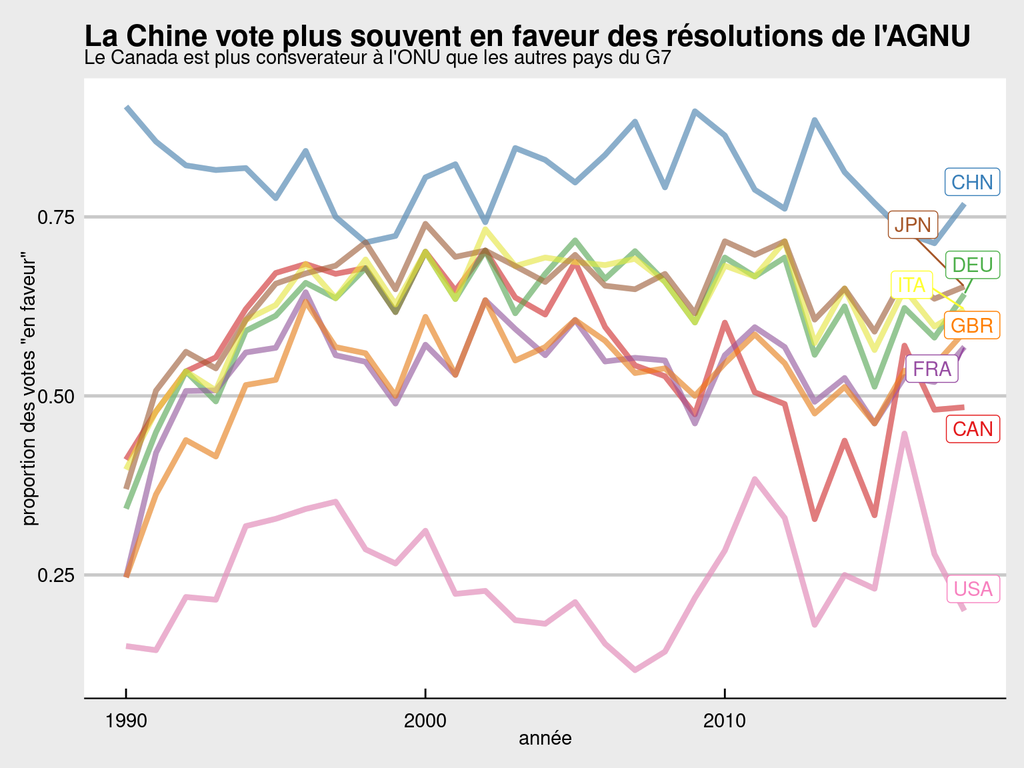

## La question moyen-orientale tire le Canada vers le bas

Cette situation change-t-elle en fonction des enjeux? Quelques observations émergent de la série de graphiques ci-dessous.

- La Chine continue de voter plus fréquemment en faveur des résolutions de l’AGNU que les pays du G7, et ce, pour tous les enjeux. À l’inverse, les États-Unis sont le pays le plus conservateur des huit.
- Sur les enjeux de développement économique, et à l’exception des États-Unis, les pays du G7 ont tendance à se montrer très favorable aux propositions de l’AGNU, si bien que l’écart avec le vote chinois est faible.
- Le “conservatisme” canadien à l’AGNU est surtout le résultat du changement dans la position canadienne face à la question palestinienne depuis 2005–changement qui a d’ailleurs survécu à l’arrivée au pouvoir d’un gouvernement libéral en 2015.
- La position du Japon est la plus “libérale” du G7 sur presque tous les enjeux.

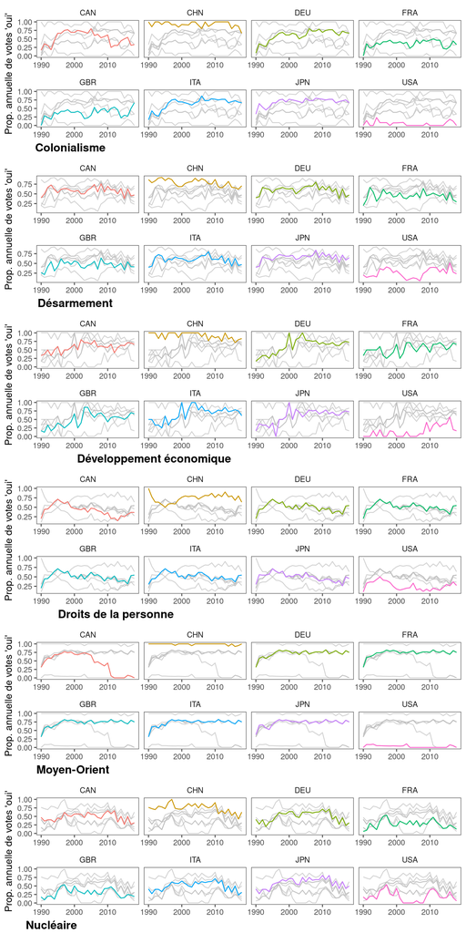

Comment l’Irlande, la Norvège, et les pays en développement se situent-ils face à ces enjeux? ————————————————————

```
## label_key: pays
## label_key: pays
## label_key: pays
## label_key: pays
## label_key: pays
## label_key: pays
```

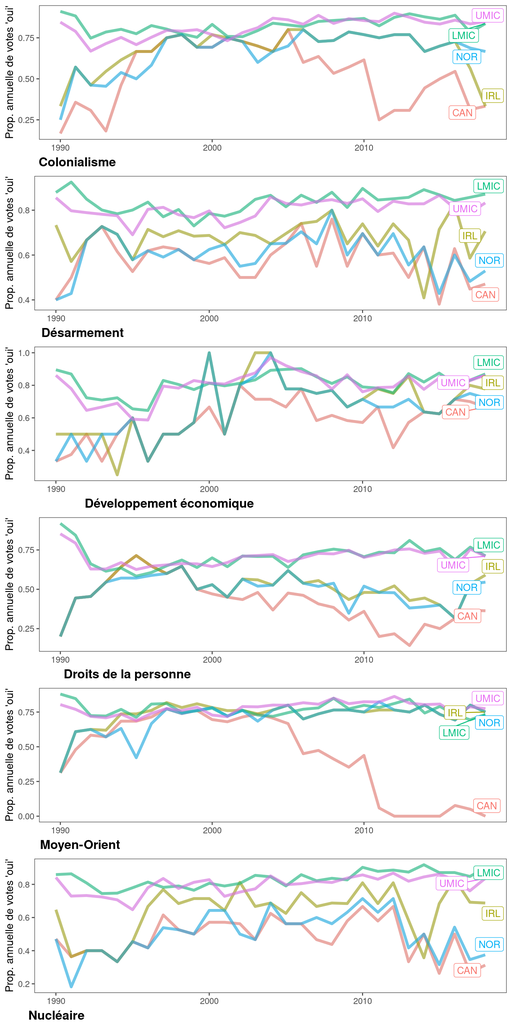